### Exploratory Analysis and Annotation of single-cell RNA-seq data

### Introduction

This R workflow will perform exploratory analysis and annotation of single-cell RNA-seq data using the `Seurat`, `celldex` and `SingleR` packages.

Human peripheral blood mononuclear cells (PBMCs) of a healthy female donor aged 25-30 were obtained by 10XGenomics from AllCells.

Libraries were generated from ~33,000 cells (23,837 cells recovered) as described in the Chromium Next GEM Single Cell 3’ HT Reagent Kits v3.1 User Guide (CG000416 Rev A) using the Chromium X and sequenced on an Illumina NovaSeq 6000 to a read depth of approximately 35,000 mean reads per cell. The data can be downloaded from 10XGenomics database:

https://www.10xgenomics.com/datasets/20-k-human-pbm-cs-3-ht-v-3-1-chromium-x-3-1-high-6-1-0

### Goals

This workflow will perform the following analyses:

- QC and Filtering
- Normalization
- Identify highly variable features
- Scale the data
- Perform Linear dimensionality reduction (PCA)
- Clustering
- Non-linear dimensionality reduction (UMAP)
- Annotation of cell types

### Setup

As in a regular R script in RStudio, a single line of code can be run with Command-Enter (Mac OS) or Ctrl-Enter (Windows). Whole chunks of code can be run with Command(/Ctrl) + Shift + Enter **or** by clicking the green “>” button in the top-right corner of the chunk. Alternatively, these options can also be implemented by selecting lines of code and choosing the desired option from the drop-down menu in the “Run” tab, in the top-right corner of the of Source section of RStudio.

To comment or uncomment a series of lines, highlight the lines and use Command(/Ctrl) + Shift + C.

R packages `SingleR`, `celldex`, `Seurat`, `tidyverse` and `pheatmap` are required for this workflow.

They can be installed using the following commands:

```r
#install.packages("SingleR")
#install.packages("celldex")
#install.packages("Seurat")
#install.packages("tidyverse")
#install.packages("pheatmap")

# If install.packages("packagename") command fails in newer versions of R uncomment and run the commands:
# if (!require("BiocManager", quietly = TRUE))
#    install.packages("BiocManager")
# BiocManager::install("packagename")
```

`Seurat` package also requires the `Matrix` as well as `SeuratObject` dependencies.

They can be installed directly from CRAN and from the developer’s website.

```r
# install.packages("https://cran.r-project.org/src/contrib/Archive/Matrix/Matrix_1.6-1.tar.gz", repos = NULL, type = "source")

# remotes::install_version("SeuratObject", "4.1.4", repos = c("https://satijalab.r-universe.dev", getOption("repos")))

# Note: `hdf5` command line tool will also need to be installed to process `.HDF5` or `.h5` files.

# First, verify the presence of `hdf5` using the command line console and if necessary, install `hdf5`, e.g. by using homebrew:

# h5dump --version

# brew install hdf5
```

Once installed, load the packages.

```r
library(SingleR)
library(celldex)
library(Seurat)
library(tidyverse)
```

```r
library(pheatmap)
```

```r
# Import data from 10X CellRanger in .HDF5 format
hdf5_obj <- Read10X_h5(filename = '~/Desktop/10XGenomics/20k_PBMC_3p_HT_nextgem_Chromium_X_filtered_feature_bc_matrix.h5',
                       use.names = TRUE,
                       unique.features = TRUE)
pbmc.seurat <- CreateSeuratObject(counts = hdf5_obj)
```

### QC and Filtering

##### It’s good practice to filter out cells where genes identified and genes with expression across cells fall below a certain threshold.

```r
# QC and Filtering
pbmc.seurat$mitoPercent <- PercentageFeatureSet(pbmc.seurat, pattern = '^MT-')
pbmc.seurat.filtered <- subset(pbmc.seurat, subset = nCount_RNA > 800 &
         nFeature_RNA > 500 &
         mitoPercent < 10)
```

### Normalization

```r
#pbmc.seurat.filtered <- NormalizeData(pbmc.seurat.filtered, normalization.method = "LogNormalize", scale.factor = 10000)
# OR
pbmc.seurat.filtered <- NormalizeData(pbmc.seurat.filtered)
str(pbmc.seurat.filtered)
```

[output not shown]

### Identify highly variable features

```
## When using repel, set xnudge and ynudge to 0 for optimal results
```

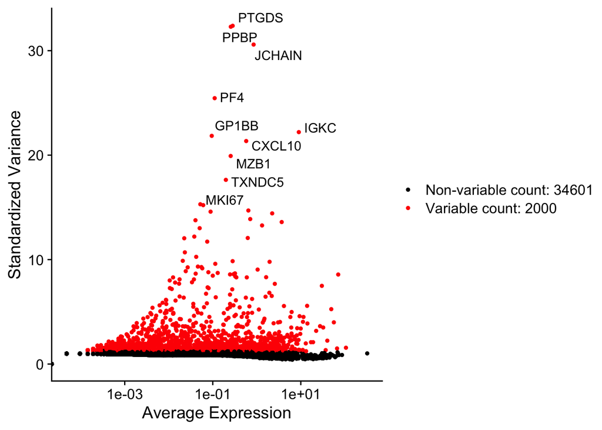

```r
# Identify highly variable features
pbmc.seurat.filtered <- FindVariableFeatures(pbmc.seurat.filtered, selection.method = "vst", nfeatures = 2000)

# Identify the 10 most highly variable genes
top10 <- head(VariableFeatures(pbmc.seurat.filtered), 10)

# plot variable features with and without labels
plot1 <- VariableFeaturePlot(pbmc.seurat.filtered)
LabelPoints(plot = plot1, points = top10, repel = TRUE)
```

### Scale the data

```r
# Scaling the data
all.genes <- rownames(pbmc.seurat.filtered)
pbmc.seurat.filtered <- ScaleData(pbmc.seurat.filtered, features = all.genes)
str(pbmc.seurat.filtered)
```

[output not shown]

[output cut: 43 more lines]

```
##   .. .. .. ..@ time.stamp : POSIXct[1:1], format: "2024-12-10 15:35:45"
##   .. .. .. ..@ assay.used : chr "RNA"
##   .. .. .. ..@ call.string: chr "ScaleData(pbmc.seurat.filtered, features = all.genes)"
##   .. .. .. ..@ params     :List of 10
##   .. .. .. .. ..$ features          : chr [1:36601] "MIR1302-2HG" "FAM138A" "OR4F5" "AL627309.1" ...
##   .. .. .. .. ..$ assay             : chr "RNA"
##   .. .. .. .. ..$ model.use         : chr "linear"
##   .. .. .. .. ..$ use.umi           : logi FALSE
##   .. .. .. .. ..$ do.scale          : logi TRUE
##   .. .. .. .. ..$ do.center         : logi TRUE
##   .. .. .. .. ..$ scale.max         : num 10
##   .. .. .. .. ..$ block.size        : num 1000
##   .. .. .. .. ..$ min.cells.to.block: num 3000
##   .. .. .. .. ..$ verbose           : logi TRUE
##   ..@ tools       : list()
```

### Perform Linear dimensionality reduction (PCA)

```r
# Perform Linear dimensionality reduction
pbmc.seurat.filtered <- RunPCA(pbmc.seurat.filtered, features = VariableFeatures(object = pbmc.seurat.filtered))
```

```
## PC_ 1
## Positive:  LTB, IL32, CD3D, CD3G, BCL11B, TRAC, TRBC2, IL7R, ARL4C, CD2
##     LIME1, TCF7, LINC00861, PRKCQ-AS1, CD7, CD27, CCR7, FCMR, TRBC1, CD247
##     LEF1, BCL2, GZMM, SYNE2, OXNAD1, IKZF3, MAL, ISG20, RASGRP1, CAMK4
## Negative:  FGL2, FCN1, MNDA, LYZ, CYBB, CTSS, CST3, TYMP, IFI30, NCF2
##     PSAP, TYROBP, SERPINA1, MPEG1, S100A9, AIF1, LST1, TMEM176B, IGSF6, DUSP6
##     TNFSF13B, FTL, CSTA, CD68, AC020656.1, GRN, DUSP1, FOS, MS4A6A, S100A8
## PC_ 2
## Positive:  IGHM, MS4A1, CD79A, BANK1, BCL11A, RALGPS2, NIBAN3, SPIB, CD79B, LINC00926
##     IGKC, AFF3, HLA-DQA1, TNFRSF13C, CD22, IGHD, TCF4, LINC02397, COBLL1, FCRL1
##     VPREB3, BLNK, PAX5, BLK, HLA-DRA, CD74, SWAP70, HLA-DPB1, GNG7, TSPAN13
## Negative:  FYB1, IL32, CD3D, CD3G, CD2, BCL11B, GZMM, TRAC, ANXA1, CD247
##     CD7, CTSW, IL7R, LINC00861, S100A4, GZMA, TMSB4X, CST7, NKG7, KLRK1
##     S100A10, TRBC1, CCL5, PRF1, PRKCQ-AS1, SAMD3, GNLY, ARL4C, KLRD1, SYNE2
## PC_ 3
## Positive:  CCR7, LTB, LEF1, IL7R, TCF7, MAL, S100A12, CD27, OXNAD1, VCAN
##     CD79A, S100A8, MS4A1, CYP1B1, CR1, CAMK4, NCF1, PADI4, CD14, LINC00926
##     CHRM3-AS2, RALGPS2, RBP7, TNFRSF13C, LRRN3, BACH2, PRKCQ-AS1, BANK1, ID3, CLEC4E
## Negative:  GZMB, NKG7, CLIC3, GNLY, CST7, KLRD1, GZMA, PRF1, FGFBP2, C12orf75
##     CCL5, HOPX, GZMH, CCL4, KLRF1, SPON2, ADGRG1, CTSC, FCGR3A, CTSW
##     PTGDR, MATK, IL2RB, CD160, PLEK, TBX21, LAIR2, TRDC, CLEC4C, LILRA4
## PC_ 4
## Positive:  FCGR3A, MTSS1, CDKN1C, HES4, ABI3, RHOC, TCF7L2, IFITM2, SIGLEC10, MS4A7
##     CD79B, HLA-DQA1, CTSL, CALHM6, HLA-DPB1, IFITM3, HLA-DPA1, BATF3, CKB, CSF1R
##     CX3CR1, CASP5, HLA-DRB5, CALML4, IER5, SMIM25, RRAS, AC104809.2, LY6E, HMOX1
## Negative:  CLEC4C, LILRA4, SERPINF1, TPM2, DNASE1L3, SCT, MAP1A, LRRC26, EPHB1, SCN9A
##     LINC00996, PACSIN1, SMPD3, PTCRA, ITM2C, LAMP5, CIB2, PHEX, TNFRSF21, ZFAT
##     PLEKHD1, NRP1, SMIM5, APP, SLC35F3, CUX2, AC007381.1, S100A12, DERL3, ALOX5AP
## PC_ 5
## Positive:  GNLY, KLRD1, NKG7, CST7, PRF1, FGFBP2, GZMA, CCL4, HOPX, KLRF1
##     GZMH, CCL5, ADGRG1, SPON2, PTGDR, MS4A1, CD160, TBX21, MATK, ITGAM
##     IL2RB, TRDC, BANK1, S100A12, FCRL3, CD79A, XCL2, LINC00926, CTSW, FCRL6
## Negative:  CDKN1C, HES4, IL3RA, NAP1L1, CTSL, TCF7L2, BATF3, CSF1R, IL7R, PLD4
##     MS4A7, CLEC4C, CKB, GUCY1A1, CASP5, RRAS, SERPINF1, LEF1, LILRA4, MS4A4A
##     CALML4, TCF7, MAL, IFITM3, RNASET2, SIGLEC10, NEURL1, TPM2, SMIM25, CD4
```

```r
# visualize PCA results
print(pbmc.seurat.filtered[["pca"]], dims = 1:5, nfeatures = 5)
```

```
## PC_ 1
## Positive:  LTB, IL32, CD3D, CD3G, BCL11B
## Negative:  FGL2, FCN1, MNDA, LYZ, CYBB
## PC_ 2
## Positive:  IGHM, MS4A1, CD79A, BANK1, BCL11A
## Negative:  FYB1, IL32, CD3D, CD3G, CD2
## PC_ 3
## Positive:  CCR7, LTB, LEF1, IL7R, TCF7
## Negative:  GZMB, NKG7, CLIC3, GNLY, CST7
## PC_ 4
## Positive:  FCGR3A, MTSS1, CDKN1C, HES4, ABI3
## Negative:  CLEC4C, LILRA4, SERPINF1, TPM2, DNASE1L3
## PC_ 5
## Positive:  GNLY, KLRD1, NKG7, CST7, PRF1
## Negative:  CDKN1C, HES4, IL3RA, NAP1L1, CTSL
```

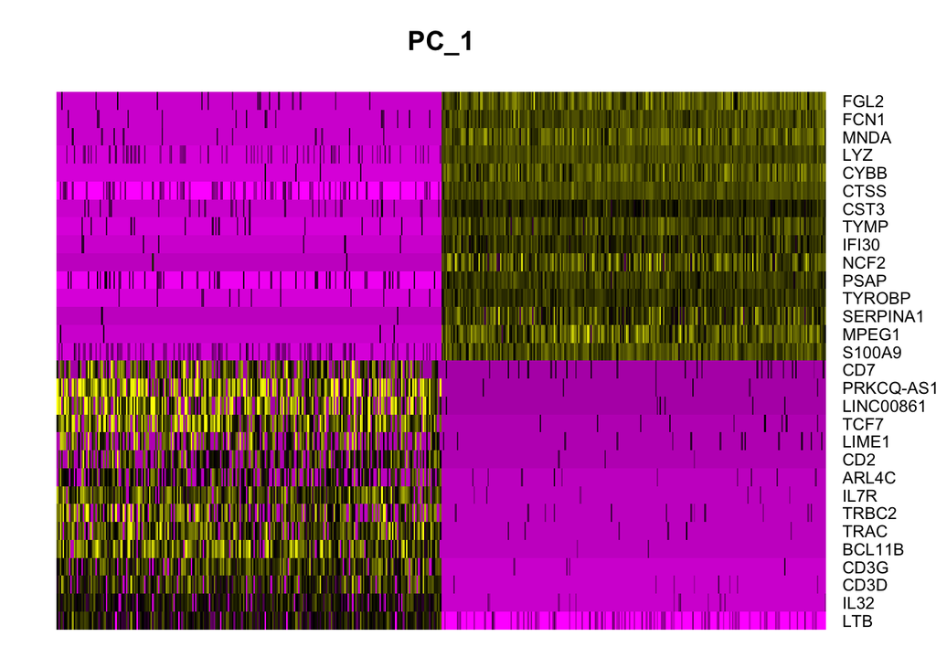

```r
DimHeatmap(pbmc.seurat.filtered, dims = 1, cells = 500, balanced = TRUE)
```

##### Creating an elbow or Scree plot is very useful for selecting the optimum number of dimensions or principal components.

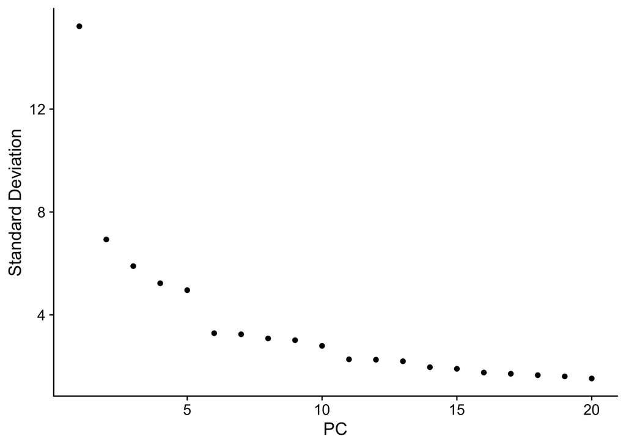

```r
# determine dimensionality of the data
ElbowPlot(pbmc.seurat.filtered)
```

### Clustering

```r
# Clustering
# In this case standard deviation or variance no longer explains the components or dimensions greater than 15
pbmc.seurat.filtered <- FindNeighbors(pbmc.seurat.filtered, dims = 1:15)
pbmc.seurat.filtered <- FindClusters(object = pbmc.seurat.filtered)
```

```
## Modularity Optimizer version 1.3.0 by Ludo Waltman and Nees Jan van Eck
##
## Number of nodes: 20844
## Number of edges: 708873
##
## Running Louvain algorithm...
## Maximum modularity in 10 random starts: 0.8921
## Number of communities: 18
## Elapsed time: 3 seconds
```

### Non-linear dimensionality reduction (UMAP)

```r
pbmc.seurat.filtered <- RunUMAP(object = pbmc.seurat.filtered, dims = 1:15)
# Alternatively, all preprocessing steps can be run as one chunk

#pbmc.seurat.filtered <- NormalizeData(object = pbmc.seurat.filtered)
#pbmc.seurat.filtered <- FindVariableFeatures(object = pbmc.seurat.filtered)
#pbmc.seurat.filtered <- ScaleData(object = pbmc.seurat.filtered)
#pbmc.seurat.filtered <- RunPCA(object = pbmc.seurat.filtered)
#pbmc.seurat.filtered <- FindNeighbors(object = pbmc.seurat.filtered, dims = 1:15)
#pbmc.seurat.filtered <- FindClusters(object = pbmc.seurat.filtered)
#pbmc.seurat.filtered <- RunUMAP(object = pbmc.seurat.filtered, dims = 1:15)
```

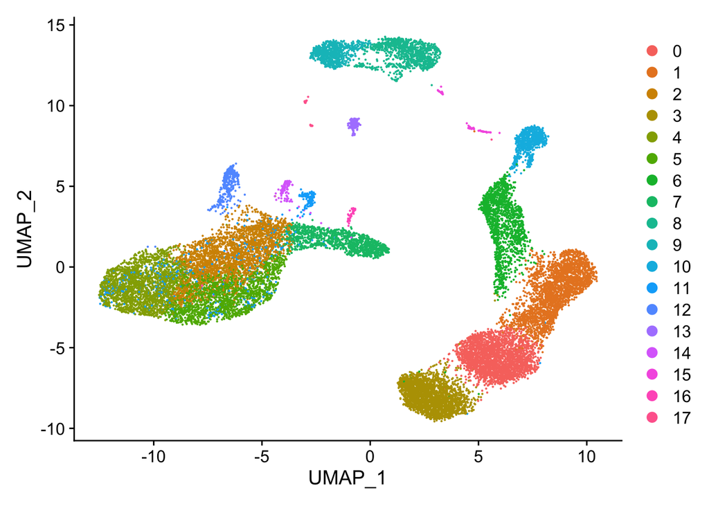

```r
#View(pbmc.seurat.filtered@meta.data)
DimPlot(pbmc.seurat.filtered, reduction = 'umap')
```

### Annotation

##### Unlike marker-based annotation that relies on traditional information of canonical marker genes that are specifically expressed in known cell types, this workflow uses the reference-based annotation strategy, which utilizes comprehensive gene expression profiles of expertly annotated reference datasets, like the Human Cell Atlas.

#### Obtain reference data using `celldex` package

```r
# obtain reference data
# expression values are provided as log normalized counts
ref <- celldex::HumanPrimaryCellAtlasData()
```

```
## snapshotDate(): 2022-10-31
```

```
## see ?celldex and browseVignettes('celldex') for documentation
```

```
## loading from cache
```

```
## see ?celldex and browseVignettes('celldex') for documentation
```

```
## loading from cache
```

```r
#View(as.data.frame(colData(ref)))
```

#### Annotate cells using `SingleR` package

```r
# run SingleR (default mode)
# by default SingleR will perform annotation of each individual cell in the test dataset

pbmc_counts <- GetAssayData(pbmc.seurat.filtered, slot = 'counts')

pred <- SingleR(test = pbmc_counts,
        ref = ref,
        labels = ref$label.main)
pred
```

```
## DataFrame with 20844 rows and 4 columns
##                                            scores      labels delta.next
##                                          <matrix> <character>  <numeric>
## AAACCCAAGAGCAGCT-1 0.143416:0.375587:0.430183:...    Monocyte  0.2635081
## AAACCCACAATACCTG-1 0.151584:0.310346:0.273554:...     T_cells  0.6537818
## AAACCCACACAACCGC-1 0.147163:0.356909:0.426418:...    Monocyte  0.2605936
## AAACCCACACACAGAG-1 0.193008:0.479521:0.479018:...    Monocyte  0.0808391
## AAACCCACAGATCATC-1 0.161458:0.389728:0.453569:...    Monocyte  0.2645277
## ...                                           ...         ...        ...
## TTTGTTGGTTCAAGGG-1 0.138897:0.285198:0.270046:...     T_cells  0.3365615
## TTTGTTGTCACCTGGG-1 0.133150:0.297344:0.270532:...     T_cells  0.0733094
## TTTGTTGTCATTGAGC-1 0.132629:0.303388:0.277882:...     T_cells  0.7014235
## TTTGTTGTCCGATGTA-1 0.174637:0.402944:0.448739:...    Monocyte  0.2994383
## TTTGTTGTCGTGGCTG-1 0.158573:0.312317:0.289688:...     T_cells  0.1709832
##                    pruned.labels
##                      <character>
## AAACCCAAGAGCAGCT-1      Monocyte
## AAACCCACAATACCTG-1       T_cells
## AAACCCACACAACCGC-1      Monocyte
## AAACCCACACACAGAG-1      Monocyte
## AAACCCACAGATCATC-1      Monocyte
## ...                          ...
## TTTGTTGGTTCAAGGG-1       T_cells
## TTTGTTGTCACCTGGG-1       T_cells
## TTTGTTGTCATTGAGC-1       T_cells
## TTTGTTGTCCGATGTA-1      Monocyte
## TTTGTTGTCGTGGCTG-1       T_cells
```

#### Label annotation results

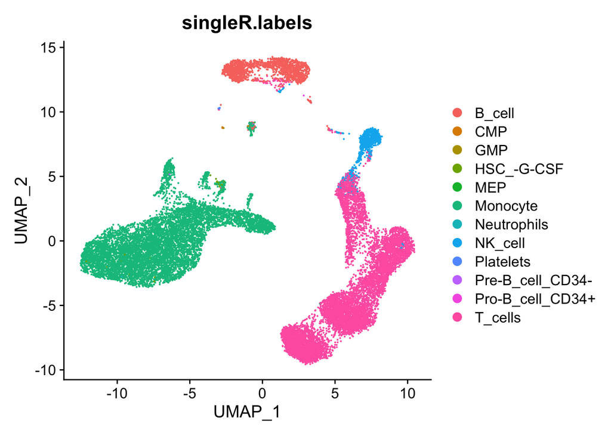

```r
pbmc.seurat.filtered$singleR.labels <- pred$labels[match(rownames(pbmc.seurat.filtered@meta.data), rownames(pred))]
DimPlot(pbmc.seurat.filtered, reduction = 'umap', group.by = 'singleR.labels')
```

#### Run annotation dignostics

```r
# Annotation diagnostics
# Based on the scores within cells
pred
```

```
## DataFrame with 20844 rows and 4 columns
##                                            scores      labels delta.next
##                                          <matrix> <character>  <numeric>
## AAACCCAAGAGCAGCT-1 0.143416:0.375587:0.430183:...    Monocyte  0.2635081
## AAACCCACAATACCTG-1 0.151584:0.310346:0.273554:...     T_cells  0.6537818
## AAACCCACACAACCGC-1 0.147163:0.356909:0.426418:...    Monocyte  0.2605936
## AAACCCACACACAGAG-1 0.193008:0.479521:0.479018:...    Monocyte  0.0808391
## AAACCCACAGATCATC-1 0.161458:0.389728:0.453569:...    Monocyte  0.2645277
## ...                                           ...         ...        ...
## TTTGTTGGTTCAAGGG-1 0.138897:0.285198:0.270046:...     T_cells  0.3365615
## TTTGTTGTCACCTGGG-1 0.133150:0.297344:0.270532:...     T_cells  0.0733094
## TTTGTTGTCATTGAGC-1 0.132629:0.303388:0.277882:...     T_cells  0.7014235
## TTTGTTGTCCGATGTA-1 0.174637:0.402944:0.448739:...    Monocyte  0.2994383
## TTTGTTGTCGTGGCTG-1 0.158573:0.312317:0.289688:...     T_cells  0.1709832
##                    pruned.labels
##                      <character>
## AAACCCAAGAGCAGCT-1      Monocyte
## AAACCCACAATACCTG-1       T_cells
## AAACCCACACAACCGC-1      Monocyte
## AAACCCACACACAGAG-1      Monocyte
## AAACCCACAGATCATC-1      Monocyte
## ...                          ...
## TTTGTTGGTTCAAGGG-1       T_cells
## TTTGTTGTCACCTGGG-1       T_cells
## TTTGTTGTCATTGAGC-1       T_cells
## TTTGTTGTCCGATGTA-1      Monocyte
## TTTGTTGTCGTGGCTG-1       T_cells
```

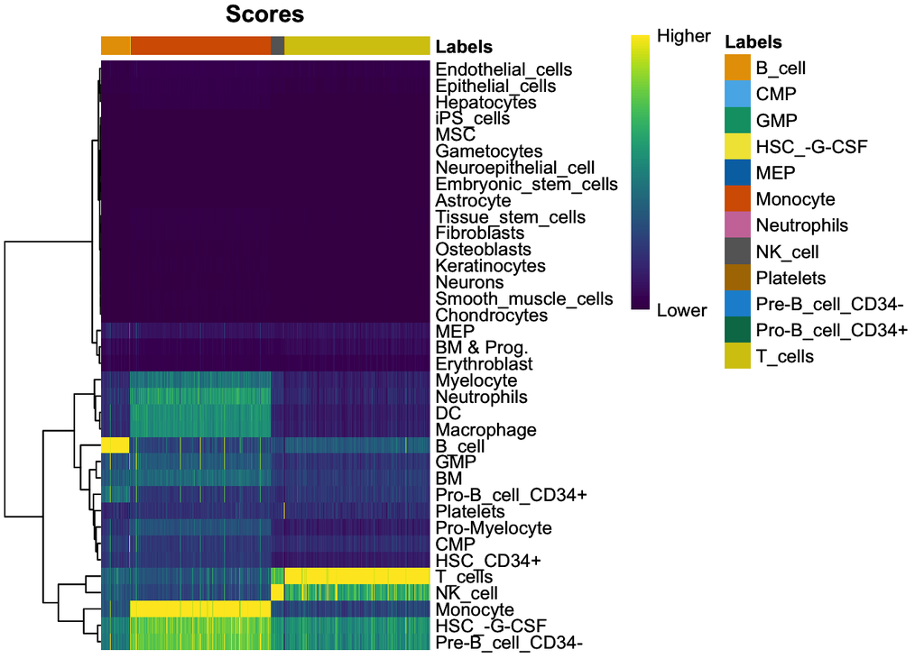

```r
#pred$scores

plotScoreHeatmap(pred)
```

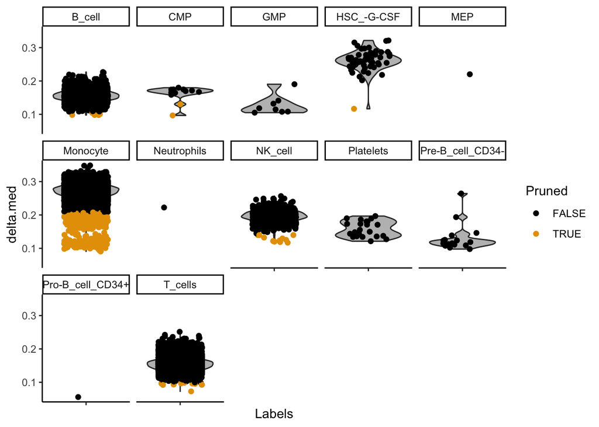

```r
# Based on deltas across cells
plotDeltaDistribution(pred)
```

#### Compare annotation results

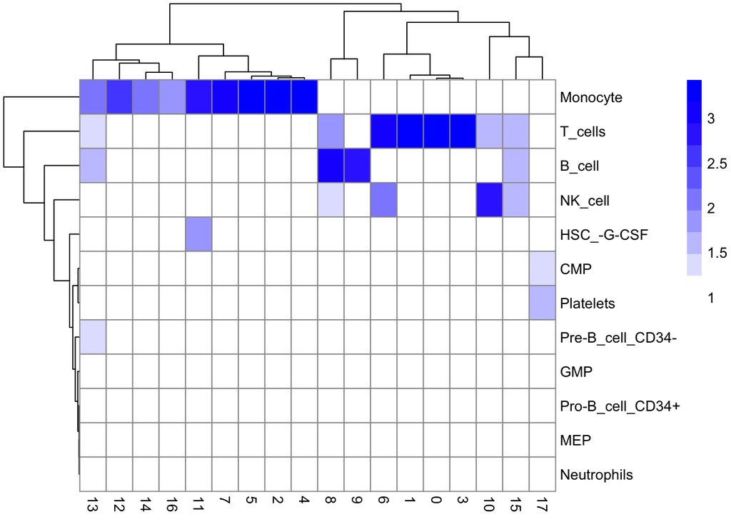

```r
# Compare annotation results to unsupervised clustering

tab <- table(Assigned=pred$labels, Clusters=pbmc.seurat.filtered$seurat_clusters)
pheatmap(log10(tab+10), color = colorRampPalette(c('white','blue'))(10))
```